# Oxford MPI Data

First, we’ll look at the relationship between a country’s MPI and its GNI per capital.

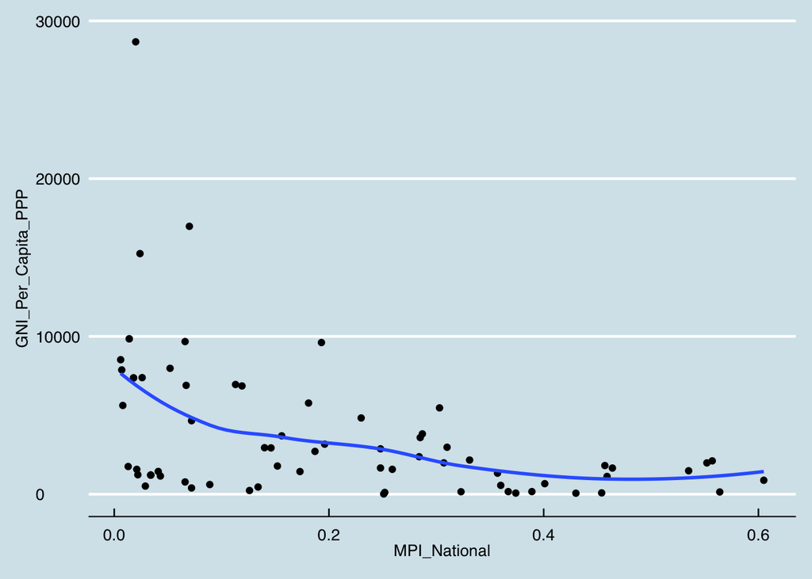

```r
df %>%
  ggplot(aes(x = MPI_National, y = GNI_Per_Capita_PPP)) +
  geom_point() +
  geom_smooth(se = FALSE) +
  theme_economist()
```

Unsurprisingly, countries with higher incomes have lower average MPI Scores. However, this relationship is hard to see due to outliers. Let’s look at just countries with GNIs less than $10,000 PPP.

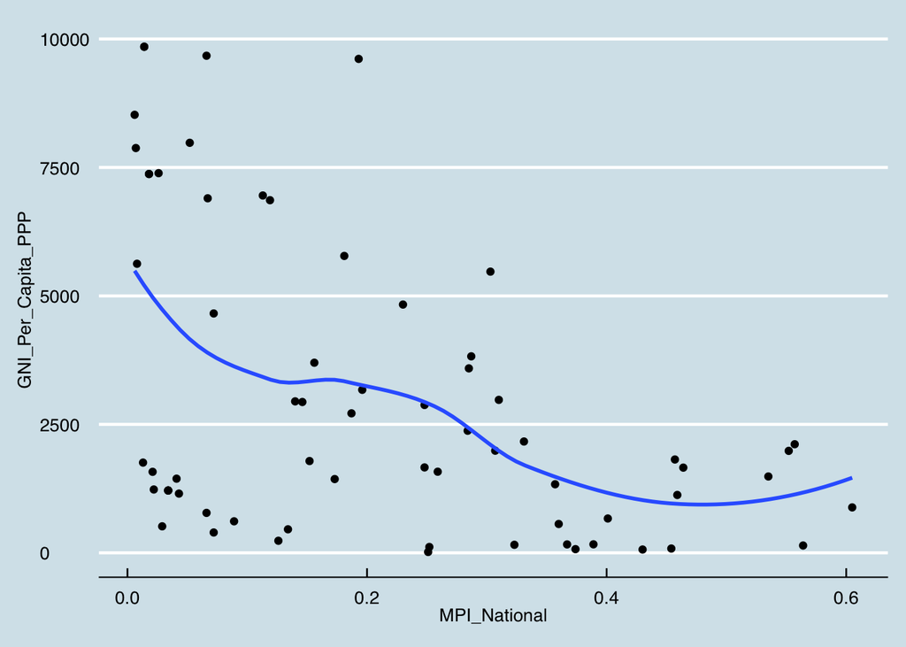

```r
df %>%
  filter(GNI_Per_Capita_PPP < 10000) %>%
  ggplot(aes(x = MPI_National, y = GNI_Per_Capita_PPP)) +
  geom_point() +
  geom_smooth(se = FALSE) +
  theme_economist()
```

It’s clear there’s a negative relationship, but the variation at the tail is interesting. It seems like countries with MPIs over 0.4 often have GNIs per capita that are higher than countries experiencing lower levels of poverty.  
Let’s explore that a bit. Here is a list of counties with MPIs above 0.4 or whose highest sub-national MPI was above 0.4. This list is ranked by GNIs per capita.

```r
df %>%
  drop_na(GNI_Per_Capita_PPP) %>%
  filter(MPI_National > .4 | Highest_MPI > .4) %>%
  mutate(Rank = min_rank(-GNI_Per_Capita_PPP)) %>%
  arrange(desc(GNI_Per_Capita_PPP)) %>%
  dplyr::select(Rank, Country, GNI_Per_Capita_PPP, MPI_Gap, MPI_National,
         Infant_Mortality_per_1000, Life_Expectancy) %>%
  kable() %>%
  kable_styling(bootstrap_options = c("striped", "hover", "condensed"), full_width = TRUE,
                position = "center", font_size = 10) %>%
  scroll_box(height = "250px")
```

| Rank | Country | GNI_Per_Capita_PPP | MPI_Gap | MPI_National | Infant_Mortality_per_1000 | Life_Expectancy |
| --- | --- | --- | --- | --- | --- | --- |
| 1 | Nigeria | 5472.25178 | 0.600 | 0.303 | 71.5 | 52.754268 |
| 2 | Pakistan | 4831.75825 | 0.363 | 0.230 | 67.4 | 66.183366 |
| 3 | Sudan | 3823.91354 | 0.454 | 0.287 | 48.8 | 63.458537 |
| 4 | Mauritania | 3589.95719 | 0.460 | 0.285 | 66.1 | 63.165854 |
| 5 | Cote d’Ivoire | 2976.74390 | 0.409 | 0.310 | 68.5 | 51.559585 |
| 6 | Cameroon | 2877.33112 | 0.516 | 0.248 | 58.6 | 55.492756 |
| 7 | Kenya | 2714.75258 | 0.489 | 0.187 | 36.6 | 61.576366 |
| 8 | Senegal | 2166.28639 | 0.293 | 0.331 | 42.3 | 66.372585 |
| 9 | South Sudan | 2113.52174 | 0.270 | 0.557 | 62.0 | 55.682220 |
| 10 | Benin | 1987.97114 | 0.445 | 0.307 | 65.7 | 59.515854 |
| 11 | Chad | 1984.47824 | 0.487 | 0.552 | 86.7 | 51.555849 |
| 12 | Mali | 1816.68736 | 0.426 | 0.457 | 75.9 | 57.986268 |
| 13 | Sierra Leone | 1658.27824 | 0.410 | 0.464 | 9.2 | 5.878785 |
| 14 | Burkina Faso | 1485.88566 | 0.491 | 0.535 | 62.2 | 58.588463 |
| 15 | Madagascar | 1334.42488 | 0.369 | 0.357 | 37.0 | 65.856976 |
| 16 | Guinea | 1125.88617 | 0.481 | 0.459 | 62.8 | 58.733439 |
| 17 | Niger | 884.24400 | 0.458 | 0.605 | 58.4 | 61.458488 |
| 18 | Congo, Democratic Republic of the | 668.18765 | 0.388 | 0.401 | 76.5 | 58.659195 |
| 19 | Timor-Leste | 561.31743 | 0.381 | 0.360 | 46.1 | 68.259146 |
| 20 | Mozambique | 165.75573 | 0.485 | 0.389 | 58.5 | 55.259512 |
| 21 | Uganda | 163.95147 | 0.558 | 0.367 | 39.1 | 58.466415 |
| 22 | Gambia | 156.67591 | 0.460 | 0.323 | 48.6 | 6.228439 |
| 23 | Ethiopia | 142.36816 | 0.578 | 0.564 | 42.9 | 64.352439 |
| 24 | Togo | 113.97649 | 0.372 | 0.252 | 53.6 | 59.655849 |
| 25 | Burundi | 83.47420 | 0.337 | 0.454 | 55.8 | 56.692244 |
| 26 | Liberia | 71.58664 | 0.286 | 0.374 | 54.7 | 6.834415 |
| 27 | Central African Republic | 64.34622 | 0.347 | 0.430 | 93.5 | 5.657785 |

We can see that Nigeria has the highest GNI per capita, yet has an Extreme MPI Gap. Nigeria also has lower life expectancy than other countries with similar GNIs per capita (Pakistan and Sudan)  
Let’s see look at Nigeria in detail. Here’s a view of its regional MPIs.

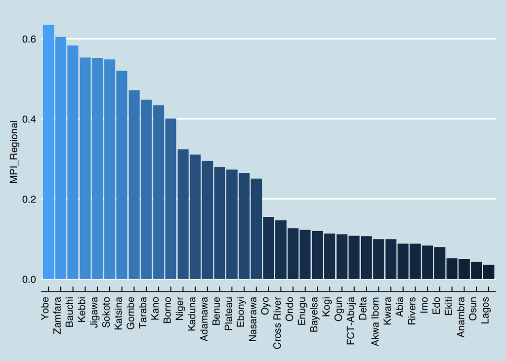

```r
subnational %>%
  filter(Country == 'Nigeria') %>%
  ggplot(mapping = aes(x = reorder(Sub_national_region, -MPI_Regional), y = MPI_Regional, fill = MPI_Regional)) +
  geom_bar(stat = 'identity') +
  theme_economist() +
  theme(axis.text.x = element_text(angle = 90, hjust = 1), axis.title.x=element_blank(), legend.position = 'none')
```

As expected, agricultural regions account for the highest MPIs and Lagos has the lowest MPI score. This view points out something interesting: Lagos is one of the most developed cities in the Africa. The comparison between max MPI and min MPI may unfairly punish nations with economically strong cities.  
To test this, let’s see where Lagos ranks in terms of all MPI regions in SSA.

```r
sub <- merge(subnational, Country_data[, c("Country_Code", "Income_Group")],
             by.x='ISO_country_code', by.y = 'Country_Code')
sub %>%
  filter(World_region == 'Sub-Saharan Africa') %>%
  mutate(Rank = min_rank(MPI_Regional)) %>%
  arrange(Rank) %>%
  dplyr::select(Rank, Sub_national_region, Country, MPI_Regional, MPI_National) %>%
  filter(Rank <= 10) %>%
  kable() %>%
  kable_styling(bootstrap_options = c("striped", "hover", "condensed"), full_width = TRUE, position = "center")
```

| Rank | Sub_national_region | Country | MPI_Regional | MPI_National |
| --- | --- | --- | --- | --- |
| 1 | Bulawayo | Zimbabwe | 0.014 | 0.152 |
| 2 | Nairobi | Kenya | 0.020 | 0.187 |
| 3 | Douala | Cameroon | 0.024 | 0.248 |
| 3 | Libreville/Port-Gentil | Gabon | 0.024 | 0.070 |
| 5 | Yaoundð | Cameroon | 0.026 | 0.248 |
| 6 | Mzuzu City | Malawi | 0.034 | 0.251 |
| 7 | Lagos | Nigeria | 0.035 | 0.303 |
| 8 | Harare | Zimbabwe | 0.038 | 0.152 |
| 9 | Dakhlett Nouadibou | Mauritania | 0.039 | 0.285 |
| 10 | Manzini | Swaziland | 0.041 | 0.066 |

```r
gaps <- gaps %>% mutate(MPI_Gap_Avg = MPI_National - Lowest_MPI)
df <- merge(gaps, WDI, by = 'ISO_country_code')
df %>%
  drop_na(GNI_Per_Capita_PPP) %>%
  filter(MPI_National > 0.4 | Highest_MPI > 0.4) %>%
  mutate(Rank = min_rank(-MPI_Gap_Avg)) %>%
  arrange(Rank) %>%
  dplyr::select(Rank, Country, MPI_Gap_Avg, Highest_MPI, Highest_Region,
         MPI_National, Lowest_MPI, Lowest_Region, MPI_Gap) %>%
  kable() %>%
  kable_styling(bootstrap_options = c("striped", "hover", "condensed"), full_width = TRUE,
                position = "center", font_size = 10) %>%
  scroll_box(height = "250px")
```

| Rank | Country | MPI_Gap_Avg | Highest_MPI | Highest_Region | MPI_National | Lowest_MPI | Lowest_Region | MPI_Gap |
| --- | --- | --- | --- | --- | --- | --- | --- | --- |
| 1 | Ethiopia | 0.479 | 0.663 | Affar | 0.564 | 0.085 | Addis Ababa | 0.578 |
| 2 | Niger | 0.399 | 0.664 | Maradi | 0.605 | 0.206 | Niamey | 0.458 |
| 3 | Mozambique | 0.346 | 0.528 | Zambðzia | 0.389 | 0.043 | Maputo Cidade | 0.485 |
| 4 | Guinea | 0.337 | 0.603 | Kankan | 0.459 | 0.122 | Conakry | 0.481 |
| 5 | Burkina Faso | 0.328 | 0.698 | Est | 0.535 | 0.207 | Centre | 0.491 |
| 6 | Congo, Democratic Republic of the | 0.299 | 0.490 | Kasað-Occidental | 0.401 | 0.102 | Kinshasa | 0.388 |
| 7 | Chad | 0.295 | 0.744 | Lac | 0.552 | 0.257 | N’DjamðNa | 0.487 |
| 8 | Uganda | 0.291 | 0.634 | Karamoja | 0.367 | 0.076 | Kampala | 0.558 |
| 9 | Burundi | 0.290 | 0.501 | Nord | 0.454 | 0.164 | Bujumbura Mairie | 0.337 |
| 10 | Mali | 0.289 | 0.594 | Mopti | 0.457 | 0.168 | Bamako | 0.426 |
| 11 | Sierra Leone | 0.273 | 0.601 | Koinadugu | 0.464 | 0.191 | Western Urban | 0.410 |
| 12 | Nigeria | 0.268 | 0.635 | Yobe | 0.303 | 0.035 | Lagos | 0.600 |
| 13 | Mauritania | 0.246 | 0.499 | Guidimagha | 0.285 | 0.039 | Dakhlett Nouadibou | 0.460 |
| 14 | Sudan | 0.240 | 0.501 | Central Darfor | 0.287 | 0.047 | Northern | 0.454 |
| 15 | Central African Republic | 0.233 | 0.544 | Basse-Kotto | 0.430 | 0.197 | Bangui | 0.347 |
| 15 | Timor-Leste | 0.233 | 0.508 | Oecussi | 0.360 | 0.127 | Dili | 0.381 |
| 17 | Gambia | 0.228 | 0.555 | Kuntaur | 0.323 | 0.095 | Banjul | 0.460 |
| 18 | Cameroon | 0.224 | 0.540 | Extrðme-Nord | 0.248 | 0.024 | Douala | 0.516 |
| 19 | Benin | 0.224 | 0.528 | Alibori | 0.307 | 0.083 | Littoral | 0.445 |
| 20 | Cote d’Ivoire | 0.201 | 0.518 | Nord-Ouest | 0.310 | 0.109 | Ville d’Abidjan | 0.409 |
| 21 | Pakistan | 0.191 | 0.402 | Balochistan | 0.230 | 0.039 | Islamabad (ICT) | 0.363 |
| 22 | Togo | 0.185 | 0.439 | Region des Savanes | 0.252 | 0.067 | Commune de Lome | 0.372 |
| 23 | Madagascar | 0.179 | 0.547 | Androy | 0.357 | 0.178 | Analamanga | 0.369 |
| 24 | Senegal | 0.175 | 0.449 | Center | 0.331 | 0.156 | Ouest | 0.293 |
| 25 | Kenya | 0.167 | 0.509 | North Eastern | 0.187 | 0.020 | Nairobi | 0.489 |
| 26 | South Sudan | 0.166 | 0.661 | Warap | 0.557 | 0.391 | Central Equatoria | 0.270 |
| 27 | Liberia | 0.124 | 0.536 | River Cess | 0.374 | 0.250 | Montserrado | 0.286 |

Here we can see that the impact of Lagos on Nigeria’s rank is minimized. Additionally, Ethiopia and Mozambique stand out as having extremely high MPI regions versus the average, indicating extreme disparity between those living in Addis Ababa/Maputo and those not.  
Let’s examine the regions of Ethiopia and Mozambique to see this. First, here’s a plot of the MPIs of Ethiopia’s regions.

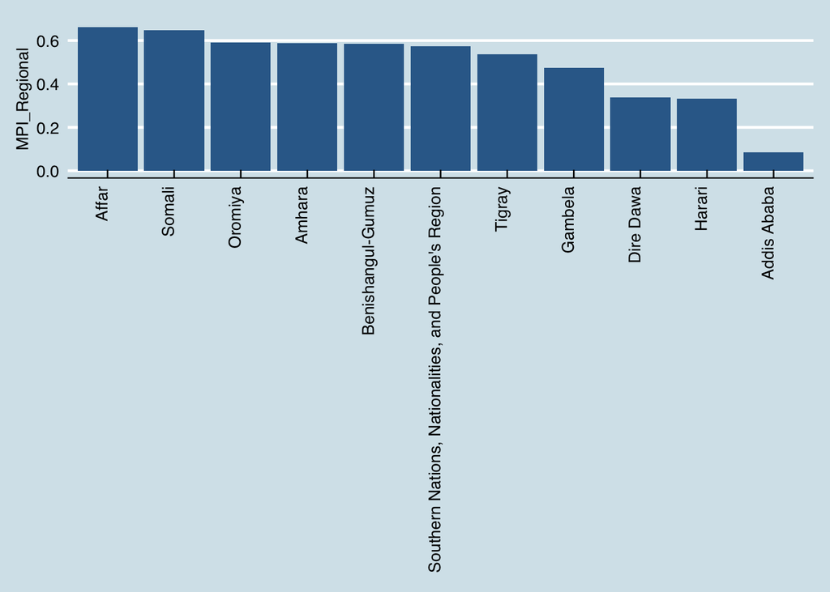

```r
subnational %>%
  filter(Country == 'Ethiopia') %>%
  ggplot(mapping = aes(x = reorder(Sub_national_region, -MPI_Regional), y = MPI_Regional, fill = MPI_National)) +
  geom_bar(stat = 'identity') +
  theme_economist() +
  theme(axis.text.x = element_text(angle = 90, hjust = 1), axis.title.x=element_blank(), legend.position = 'none')
```

Now, here’s a plot of the MPIs of Mozambique’s regions.

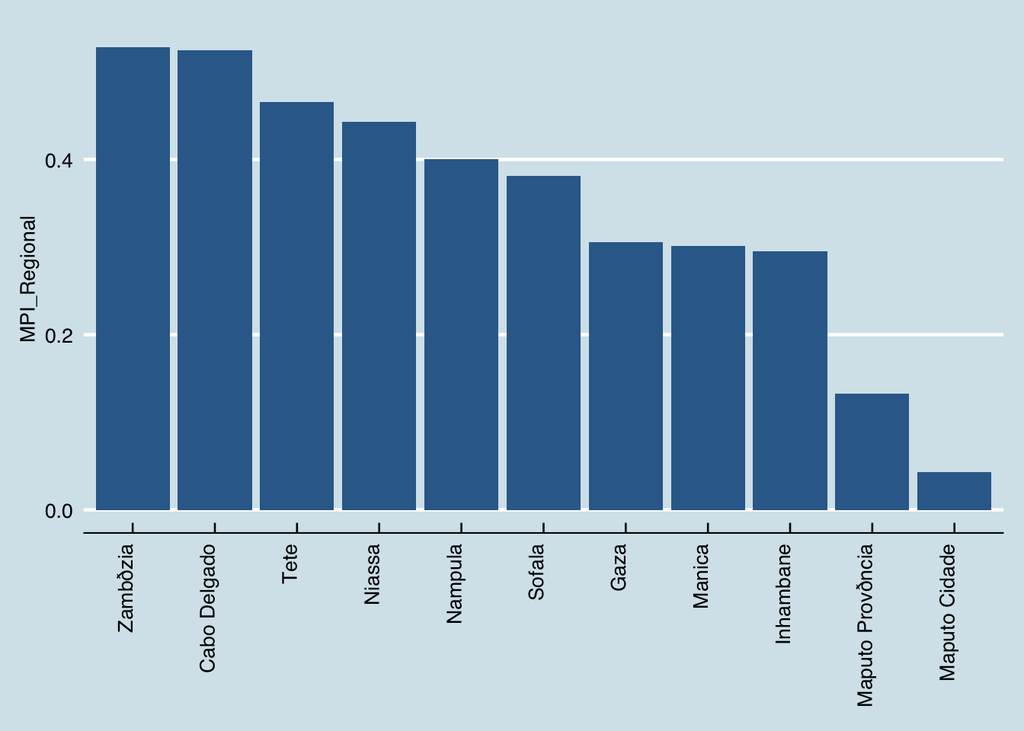

```r
subnational %>%
  filter(Country == 'Mozambique') %>%
  ggplot(mapping = aes(x = reorder(Sub_national_region, -MPI_Regional), y = MPI_Regional, fill = MPI_National)) +
  geom_bar(stat = 'identity') +
  theme_economist() +
  theme(axis.text.x = element_text(angle = 90, hjust = 1), axis.title.x=element_blank(), legend.position = 'none')
```

```r
sub <- subnational %>%
  group_by(Country) %>%
  mutate(ranks = order(order(MPI_Regional))) %>%
  arrange(Country, ranks) %>%
  mutate(lag_MPI = MPI_Regional - lag(MPI_Regional)) %>%
  filter(ranks == 2)
df <- merge(df, sub[, c('ISO_country_code', 'lag_MPI')], by = 'ISO_country_code') %>%
  rename(MPI_Jump = lag_MPI)
df %>%
  drop_na(GNI_Per_Capita_PPP) %>%
  filter(MPI_National > 0.4 | Highest_MPI > 0.4) %>%
  mutate(Rank = min_rank(-MPI_Jump)) %>%
  arrange(Rank) %>%
  dplyr::select(Rank, Country, MPI_Jump, MPI_Gap_Avg, Highest_MPI, Highest_Region,
         MPI_National, Lowest_MPI, Lowest_Region) %>%
  kable() %>%
  kable_styling(bootstrap_options = c("striped", "hover", "condensed"), full_width = TRUE,
                position = "center", font_size = 10) %>%
  scroll_box(height = "250px")
```

| Rank | Country | MPI_Jump | MPI_Gap_Avg | Highest_MPI | Highest_Region | MPI_National | Lowest_MPI | Lowest_Region |
| --- | --- | --- | --- | --- | --- | --- | --- | --- |
| 1 | Guinea | 0.296 | 0.337 | 0.603 | Kankan | 0.459 | 0.122 | Conakry |
| 2 | Mali | 0.272 | 0.289 | 0.594 | Mopti | 0.457 | 0.168 | Bamako |
| 3 | Burundi | 0.258 | 0.290 | 0.501 | Nord | 0.454 | 0.164 | Bujumbura Mairie |
| 4 | Burkina Faso | 0.252 | 0.328 | 0.698 | Est | 0.535 | 0.207 | Centre |
| 5 | Ethiopia | 0.248 | 0.479 | 0.663 | Affar | 0.564 | 0.085 | Addis Ababa |
| 6 | Congo, Democratic Republic of the | 0.247 | 0.299 | 0.490 | Kasað-Occidental | 0.401 | 0.102 | Kinshasa |
| 7 | Uganda | 0.218 | 0.291 | 0.634 | Karamoja | 0.367 | 0.076 | Kampala |
| 8 | Senegal | 0.217 | 0.175 | 0.449 | Center | 0.331 | 0.156 | Ouest |
| 9 | Niger | 0.199 | 0.399 | 0.664 | Maradi | 0.605 | 0.206 | Niamey |
| 10 | Togo | 0.169 | 0.185 | 0.439 | Region des Savanes | 0.252 | 0.067 | Commune de Lome |
| 11 | Timor-Leste | 0.168 | 0.233 | 0.508 | Oecussi | 0.360 | 0.127 | Dili |
| 12 | Central African Republic | 0.167 | 0.233 | 0.544 | Basse-Kotto | 0.430 | 0.197 | Bangui |
| 13 | Cote d’Ivoire | 0.155 | 0.201 | 0.518 | Nord-Ouest | 0.310 | 0.109 | Ville d’Abidjan |
| 14 | Benin | 0.155 | 0.224 | 0.528 | Alibori | 0.307 | 0.083 | Littoral |
| 15 | Chad | 0.154 | 0.295 | 0.744 | Lac | 0.552 | 0.257 | N’DjamðNa |
| 16 | Pakistan | 0.145 | 0.191 | 0.402 | Balochistan | 0.230 | 0.039 | Islamabad (ICT) |
| 17 | Sierra Leone | 0.128 | 0.273 | 0.601 | Koinadugu | 0.464 | 0.191 | Western Urban |
| 18 | Liberia | 0.099 | 0.124 | 0.536 | River Cess | 0.374 | 0.250 | Montserrado |
| 19 | Madagascar | 0.091 | 0.179 | 0.547 | Androy | 0.357 | 0.178 | Analamanga |
| 20 | Mozambique | 0.090 | 0.346 | 0.528 | Zambðzia | 0.389 | 0.043 | Maputo Cidade |
| 21 | South Sudan | 0.065 | 0.166 | 0.661 | Warap | 0.557 | 0.391 | Central Equatoria |
| 22 | Gambia | 0.062 | 0.228 | 0.555 | Kuntaur | 0.323 | 0.095 | Banjul |
| 23 | Kenya | 0.055 | 0.167 | 0.509 | North Eastern | 0.187 | 0.020 | Nairobi |
| 24 | Mauritania | 0.046 | 0.246 | 0.499 | Guidimagha | 0.285 | 0.039 | Dakhlett Nouadibou |
| 25 | Sudan | 0.030 | 0.240 | 0.501 | Central Darfor | 0.287 | 0.047 | Northern |
| 26 | Nigeria | 0.008 | 0.268 | 0.635 | Yobe | 0.303 | 0.035 | Lagos |
| 27 | Cameroon | 0.002 | 0.224 | 0.540 | Extrðme-Nord | 0.248 | 0.024 | Douala |

In these countries, one urban area is dramatically more developed than all other regions. Such a drop could indicate rural neglect, corruption, or localized industry.

### Conclusion

Ultimately, this analysis has shown that there are significant intra- and intercountry differences in poverty. This underscores that poverty must not be considered simply a national battle. Poverty reduction relies on understanding regional differences and working with local actors to plan interventions. As Robert Chambers [(1995)](https://doi.org/10.1177/095624789500700106) describes, this process relies on development practitioners listening to local realities and shifting accountability out of development centers.